# R Notebook

**Principles of Data Visualization and Introduction to ggplot2**

I have provided you with data about the 5,000 fastest growing companies in the US, as compiled by Inc. magazine. lets read this in:

```r
inc <- read.csv("https://raw.githubusercontent.com/charleyferrari/CUNY_DATA_608/master/module1/Data/inc5000_data.csv", header= TRUE)
```

And lets preview this data:

```r
head(inc)
```

|  | Rank | Name | Growth_Rate | Revenue | Industry | Employees | City | State |
| --- | --- | --- | --- | --- | --- | --- | --- | --- |
| 1 | 1 | Fuhu | 421.48 | 117900000 | Consumer Products & Services | 104 | El Segundo | CA |
| 2 | 2 | FederalConference.com | 248.31 | 49600000 | Government Services | 51 | Dumfries | VA |
| 3 | 3 | The HCI Group | 245.45 | 25500000 | Health | 132 | Jacksonville | FL |
| 4 | 4 | Bridger | 233.08 | 1900000000 | Energy | 50 | Addison | TX |
| 5 | 5 | DataXu | 213.37 | 87000000 | Advertising & Marketing | 220 | Boston | MA |
| 6 | 6 | MileStone Community Builders | 179.38 | 45700000 | Real Estate | 63 | Austin | TX |

```r
NA
```

```r
summary(inc)
```

```
      Rank                          Name       Growth_Rate         Revenue
 Min.   :   1   (Add)ventures         :   1   Min.   :  0.340   Min.   :    2000000
 1st Qu.:1252   @Properties           :   1   1st Qu.:  0.770   1st Qu.:    5100000
 Median :2502   1-Stop Translation USA:   1   Median :  1.420   Median :   10900000
 Mean   :2502   110 Consulting        :   1   Mean   :  4.612   Mean   :   48222535
 3rd Qu.:3751   11thStreetCoffee.com  :   1   3rd Qu.:  3.290   3rd Qu.:   28600000
 Max.   :5000   123 Exteriors         :   1   Max.   :421.480   Max.   :10100000000
                (Other)               :4995
                         Industry      Employees                  City          State
 IT Services                 : 733   Min.   :    1.0   New York     : 160   CA     : 701
 Business Products & Services: 482   1st Qu.:   25.0   Chicago      :  90   TX     : 387
 Advertising & Marketing     : 471   Median :   53.0   Austin       :  88   NY     : 311
 Health                      : 355   Mean   :  232.7   Houston      :  76   VA     : 283
 Software                    : 342   3rd Qu.:  132.0   San Francisco:  75   FL     : 282
 Financial Services          : 260   Max.   :66803.0   Atlanta      :  74   IL     : 273
 (Other)                     :2358   NA's   :12        (Other)      :4438   (Other):2764
```

Think a bit on what these summaries mean. Use the space below to add some more relevant non-visual exploratory information you think helps you understand this data:

```r
# turn off scientific notation
options(scipen = 999)

# load package
library(tidyverse)
library(knitr)
library(purrr)

# what is the structure of this data object?
str(inc)
```

```
'data.frame':   5001 obs. of  8 variables:
 $ Rank       : int  1 2 3 4 5 6 7 8 9 10 ...
 $ Name       : Factor w/ 5001 levels "(Add)ventures",..: 1770 1633 4423 690 1198 2839 4733 1468 1869 4968 ...
 $ Growth_Rate: num  421 248 245 233 213 ...
 $ Revenue    : num  117900000 49600000 25500000 1900000000 87000000 ...
 $ Industry   : Factor w/ 25 levels "Advertising & Marketing",..: 5 12 13 7 1 20 10 1 5 21 ...
 $ Employees  : int  104 51 132 50 220 63 27 75 97 15 ...
 $ City       : Factor w/ 1519 levels "Acton","Addison",..: 391 365 635 2 139 66 912 1179 131 1418 ...
 $ State      : Factor w/ 52 levels "AK","AL","AR",..: 5 47 10 45 20 45 44 5 46 41 ...
```

```r
# what is the length of unique value for each variable?
sapply(inc, function(x) length(unique(x)))
```

```
       Rank        Name Growth_Rate     Revenue    Industry   Employees        City       State
       4999        5001        1147        1069          25         692        1519          52
```

```r
# any missing valuae?
colSums(is.na(inc))
```

```
       Rank        Name Growth_Rate     Revenue    Industry   Employees        City       State
          0           0           0           0           0          12           0           0
```

```r
# Let's take a look of these top companies by state, i.e. where do they locate?
inc <- inc %>%
        dplyr::mutate(rank_bucket = cut(inc$Rank, breaks = seq(from = 0, to = length(inc$Rank), by = 100), labels = paste0("top ", 1:50, " tier")))  # cut by every 100 companies

# CA, TX followed by NY seem to have the best companies in terms of fastest growth rate
ftable(inc$rank_bucket, inc$State)  # additionally, we can present it as heatmap
```

```
             AK AL AR AZ CA CO CT DC DE FL GA HI IA ID IL IN KS KY LA MA MD ME MI MN MO MS MT NC ND NE NH NJ NM NV NY OH OK OR PA PR RI SC SD TN TX UT VA VT WA WI WV WY

top 1 tier    0  0  0  2 17  5  2  2  0  7  2  0  0  0  4  2  0  0  0  5  2  2  1  1  0  1  0  1  0  0  0  1  0  0  7  3  1  0  1  0  2  1  0  2 14  3  4  0  3  1  0  1
top 2 tier    0  0  0  3 20  2  2  3  0  3  4  0  0  0  5  3  2  0  0  6  5  1  0  2  1  0  0  2  0  1  0  5  0  0  4  2  0  2  2  0  0  1  0  0 10  1  6  0  1  1  0  0
top 3 tier    0  1  0  2 18  2  0  1  0 12  1  2  0  0  5  1  1  0  0  3  3  0  1  1  0  0  0  4  0  0  0  6  0  0  9  3  0  0  1  0  0  1  0  0  9  4  6  0  1  1  0  0
top 4 tier    0  1  0  1 19  4  1  3  0  6  4  0  0  0  6  0  1  0  0  3  3  0  0  4  0  0  0  2  0  0  0  6  0  1  4  1  0  1  3  0  1  2  0  4  7  4  6  0  1  1  0  0
top 5 tier    1  2  0  3 14  1  2  0  0  6  7  1  1  1  6  1  0  1  0  4  6  0  2  0  1  1  0  3  0  0  0  3  0  1  5  4  0  1  1  0  0  2  0  3 10  0  3  0  3  0  0  0
top 6 tier    0  0  0  4 20  3  0  1  0  9  5  0  0  1  4  2  0  0  2  3  6  0  1  0  2  0  0  1  0  0  0  4  0  1  6  1  1  1  0  0  1  0  0  0  4  6  3  0  8  0  0  0
top 7 tier    0  0  0  1 18  2  1  1  2  8  5  0  1  0  3  3  1  1  0  5  3  0  3  2  1  1  0  3  0  1  0  4  0  0  6  4  0  1  2  0  1  1  0  0  8  2  2  0  1  2  0  0
top 8 tier    0  0  1  1 20  2  3  1  1  1  4  0  1  1  5  4  2  0  0  5  1  0  0  2  0  0  0  1  0  0  0  1  0  0 10  4  2  1  4  0  1  2  0  2  5  4  4  0  4  0  0  0
top 9 tier    0  1  0  1 15  2  0  0  0  5  3  0  0  0  6  0  0  3  1  4  3  0  1  3  2  0  0  0  0  0  0  3  0  1  9  8  1  1  3  0  0  0  0  2  6  1 11  0  1  3  0  0
top 10 tier   0  1  0  2 20  2  0  0  0  6  5  0  0  1  9  4  0  2  0  0  2  0  2  3  2  0  0  5  0  0  0  1  0  0  3  4  2  0  1  0  0  0  0  0  7  4 10  0  2  0  0  0
top 11 tier   0  2  0  1 16  1  1  1  0  6  3  0  0  1  7  1  0  1  2  5  1  1  2  1  0  0  0  5  0  0  1  2  0  0 11  1  1  1  2  0  1  2  0  1  6  0 10  0  2  1  0  0
top 12 tier   0  1  1  3 24  4  1  0  1 13  2  0  0  0  4  2  0  0  0  2  2  0  1  1  0  0  0  3  0  0  1  1  0  0  5  2  1  1  3  0  0  2  0  1 10  1  5  0  2  0  0  0
top 13 tier   0  3  0  0 13  1  3  2  0  4  3  0  1  0  5  3  0  0  2  6  3  0  1  3  0  0  0  4  0  0  0  2  0  0  6  2  1  1  8  0  0  1  0  1  9  0  8  0  2  2  0  0
top 14 tier   0  0  0  2 17  2  1  1  0  3  5  0  0  0  8  0  0  1  0  3  2  1  5  3  1  0  0  4  0  1  1  4  0  0  2  8  2  1  3  0  0  0  0  4  5  2  4  0  1  3  0  0
top 15 tier   0  1  0  1 13  3  0  0  0  9  7  0  0  0  9  2  0  0  0  2  4  1  5  2  2  0  0  3  0  0  0  3  0  0  7  2  0  0  2  0  1  1  0  0  8  2  7  0  3  0  0  0
top 16 tier   0  0  1  4 16  2  1  1  0  5  4  1  1  0  6  1  2  0  1  1  4  0  4  1  1  0  0  4  0  0  1  1  1  0  4  3  0  0  4  0  2  0  0  3  8  5  5  1  1  0  0  0
top 17 tier   0  1  0  3 10  4  0  2  0  3  8  0  0  0  2  1  0  1  0  5  5  1  4  2  1  0  0  4  0  0  2  2  0  2  5  1  1  0  1  0  0  2  0  0  8  3  6  0  6  4  0  0
top 18 tier   0  0  0  2 13  6  0  1  0  6  7  0  0  0  5  3  0  0  0  4  2  0  3  0  0  0  0  8  0  0  1  5  0  0  6  3  0  0  1  0  1  1  1  0  7  2  6  0  4  2  0  0
top 19 tier   0  2  0  2 12  4  1  1  0  7  3  0  0  1  5  2  0  1  2  3  4  0  2  2  2  0  0  1  1  0  0  4  0  1  4  2  0  1  6  0  0  2  0  0 12  1  5  1  3  0  0  0
top 20 tier   0  0  0  2  9  3  1  2  1  6  3  1  0  0  6  0  1  2  0  6  2  0  3  3  1  0  0  3  1  0  0  3  0  0  5  4  2  1  3  0  0  3  0  2 11  3  3  0  3  1  0  0
top 21 tier   0  0  0  1 13  5  0  1  1  7  3  1  0  1  7  2  1  1  1  5  3  1  5  1  2  0  0  3  0  0  0  2  0  1  3  5  2  1  1  0  0  0  0  3  7  1  6  0  2  1  0  0
top 22 tier   0  1  0  5 11  3  0  0  1  4  2  0  0  1  5  2  0  1  1  3  1  0  5  1  3  0  0  1  0  0  0  2  1  0  5  2  1  1  9  1  0  1  0  0  9  3  6  0  7  1  0  0
top 23 tier   0  1  0  1  8  3  1  1  0  7  4  0  2  0  6  0  0  0  2  3  3  0  0  3  0  0  0  3  0  0  1 11  0  0  5  5  1  1  4  0  0  0  0  0 10  0  9  0  2  3  0  0
top 24 tier   0  0  0  3 11  8  1  0  2  4  4  0  0  0  6  1  3  1  1  4  1  0  2  1  2  0  0  2  1  0  1  2  0  0  4  3  1  4  9  0  1  0  0  1  6  1  6  0  3  0  0  0
top 25 tier   0  3  0  2 16  1  1  1  0  7  6  0  1  0  6  0  2  1  1  0  3  0  2  2  0  0  0  2  0  2  0  3  0  4  6  2  1  1  5  0  1  2  0  0  4  1  8  0  1  2  0  0
top 26 tier   0  2  0  1 10  2  1  1  0  9  6  0  0  0  4  1  1  0  1  5  2  1  2  0  1  0  0  2  0  1  2  6  1  1  9  4  0  0  1  0  0  1  0  2  7  2  5  0  5  1  0  0
top 27 tier   0  3  0  1 17  1  2  0  1  6  6  0  0  1  3  0  1  3  1  3  4  0  3  1  3  1  0  1  0  0  0  3  0  0  5  3  2  1  2  0  0  0  0  5  9  1  5  0  2  0  0  0
top 28 tier   0  1  0  2 12  1  2  0  1  7  3  0  0  0  4  1  0  0  0  3  2  0  2  1  0  1  0  0  1  1  0  3  0  0  9  8  1  1  4  0  0  0  0  2 13  3  8  0  2  1  0  0
top 29 tier   0  0  0  1 19  1  0  0  0  1  5  0  2  0  5  5  0  0  1  3  2  0  2  1  0  0  0  4  0  0  2  1  0  1  7  3  2  2  2  0  0  1  0  4  9  2  6  0  4  2  0  0
top 30 tier   0  0  0  2 13  3  2  1  0  4  7  0  0  1  5  1  1  1  2  4  3  0  4  4  1  1  1  0  0  1  1  5  0  0  6  3  0  1  3  0  0  1  0  0  6  2  6  0  2  2  0  0
top 31 tier   0  2  0  2 17  1  2  0  2  3  2  0  0  0  4  5  2  1  1  4  2  1  6  2  2  0  0  2  1  1  0  1  0  0  6  5  2  0  4  0  1  0  0  0  1  3  4  0  5  3  0  0
top 32 tier   0  1  0  2 15  3  1  0  0  5  5  0  1  0  4  1  1  2  1  3  3  0  2  2  0  1  0  5  1  0  0  4  0  0  8  1  2  0  5  0  1  1  1  0  6  2  6  1  2  1  0  0
```

[output cut: 18 more lines]

```r
# what is the average growth rate by rank_bucket?
inc %>%
        dplyr::select(Growth_Rate, rank_bucket) %>%
        group_by(rank_bucket) %>%
        summarise(avg.growth = round(mean(Growth_Rate), 1)) %>%
        kable()
```

| rank_bucket | avg.growth |
| --- | --- |
| top 1 tier | 76.9 |
| top 2 tier | 26.1 |
| top 3 tier | 17.3 |
| top 4 tier | 12.5 |
| top 5 tier | 10.2 |
| top 6 tier | 8.3 |
| top 7 tier | 7.1 |
| top 8 tier | 6.1 |
| top 9 tier | 5.3 |
| top 10 tier | 4.6 |
| top 11 tier | 4.0 |
| top 12 tier | 3.6 |
| top 13 tier | 3.3 |
| top 14 tier | 3.0 |
| top 15 tier | 2.8 |
| top 16 tier | 2.6 |
| top 17 tier | 2.4 |
| top 18 tier | 2.2 |
| top 19 tier | 2.1 |
| top 20 tier | 1.9 |
| top 21 tier | 1.8 |
| top 22 tier | 1.7 |
| top 23 tier | 1.6 |
| top 24 tier | 1.5 |
| top 25 tier | 1.5 |
| top 26 tier | 1.4 |
| top 27 tier | 1.3 |
| top 28 tier | 1.3 |
| top 29 tier | 1.2 |
| top 30 tier | 1.2 |
| top 31 tier | 1.1 |
| top 32 tier | 1.0 |
| top 33 tier | 1.0 |
| top 34 tier | 0.9 |
| top 35 tier | 1.1 |
| top 36 tier | 0.9 |
| top 37 tier | 0.8 |
| top 38 tier | 0.8 |
| top 39 tier | 0.7 |
| top 40 tier | 0.7 |
| top 41 tier | 0.7 |
| top 42 tier | 0.6 |
| top 43 tier | 0.6 |
| top 44 tier | 0.6 |
| top 45 tier | 0.5 |
| top 46 tier | 0.5 |
| top 47 tier | 0.5 |
| top 48 tier | 0.4 |
| top 49 tier | 0.4 |
| top 50 tier | 0.4 |

```r
# what is the average revenue by rank_bucket?
inc %>%
        dplyr::select(Revenue, rank_bucket) %>%
        group_by(rank_bucket) %>%
        summarise(`avg.revenue (in million)` = round(mean(Revenue / 1000000), 1)) %>%  # divided by million
        kable()
```

| rank_bucket | avg.revenue (in million) |
| --- | --- |
| top 1 tier | 52.3 |
| top 2 tier | 20.7 |
| top 3 tier | 13.4 |
| top 4 tier | 18.4 |
| top 5 tier | 30.1 |
| top 6 tier | 21.0 |
| top 7 tier | 18.0 |
| top 8 tier | 25.3 |
| top 9 tier | 20.7 |
| top 10 tier | 38.2 |
| top 11 tier | 28.5 |
| top 12 tier | 32.6 |
| top 13 tier | 41.3 |
| top 14 tier | 57.0 |
| top 15 tier | 55.1 |
| top 16 tier | 21.8 |
| top 17 tier | 23.6 |
| top 18 tier | 32.8 |
| top 19 tier | 50.6 |
| top 20 tier | 44.7 |
| top 21 tier | 31.5 |
| top 22 tier | 36.2 |
| top 23 tier | 56.7 |
| top 24 tier | 36.5 |
| top 25 tier | 43.9 |
| top 26 tier | 53.5 |
| top 27 tier | 29.1 |
| top 28 tier | 22.7 |
| top 29 tier | 37.4 |
| top 30 tier | 57.4 |
| top 31 tier | 38.8 |
| top 32 tier | 35.4 |
| top 33 tier | 23.8 |
| top 34 tier | 39.7 |
| top 35 tier | 92.8 |
| top 36 tier | 34.8 |
| top 37 tier | 49.1 |
| top 38 tier | 54.7 |
| top 39 tier | 106.3 |
| top 40 tier | 43.3 |
| top 41 tier | 75.2 |
| top 42 tier | 36.3 |
| top 43 tier | 76.1 |
| top 44 tier | 41.7 |
| top 45 tier | 43.1 |
| top 46 tier | 56.7 |
| top 47 tier | 64.6 |
| top 48 tier | 200.1 |
| top 49 tier | 99.1 |
| top 50 tier | 146.7 |

```r
# is there any correlation between growth rate and revenue by rank_bucket?
tempVector <- c()

for(i in 1:length(unique(inc$rank_bucket))){

        x <- inc %>%
                dplyr::filter(rank_bucket == unique(rank_bucket)[i]) %>%
                dplyr::select(Growth_Rate) %>%
                unlist

        y <- inc %>%
                dplyr::filter(rank_bucket == unique(rank_bucket)[i]) %>%
                dplyr::select(Revenue) %>%
                unlist

        tempResult <- cor(x, y)

        tempVector <- c(tempResult, tempVector)
}

names(tempVector) <- paste0("top tier ", 50:1)

tempVector %>%
        as.data.frame %>%
        dplyr::mutate(tier = paste0("top tier ", 50:1),
                      row = row_number()) %>%
        arrange(desc(row)) %>%
        dplyr::select(tier, correlation = ".")
```

| tier | correlation |
| --- | --- |
| top tier 1 | 0.312134426 |
| top tier 2 | 0.019263529 |
| top tier 3 | 0.029271685 |
| top tier 4 | -0.058751919 |
| top tier 5 | 0.065139682 |
| top tier 6 | 0.152399343 |
| top tier 7 | 0.014879952 |
| top tier 8 | -0.117365545 |
| top tier 9 | -0.077989624 |
| top tier 10 | -0.025260574 |

[output cut: 40 more lines]

```r
# there is no correlation
```

```r
# it does not seem to have a strong correlation between growth rate and revenue by rank, perhaps it makes more sense to look at the relationship by industry segment

tempList <- vector(mode = "list")

for(i in 1:length(unique(inc$Industry))){

        industry <- unique(inc$Industry)[i] %>% as.character()

        x <- inc %>%
                dplyr::filter(Industry == unique(Industry)[i]) %>%
                dplyr::select(Growth_Rate) %>%
                unlist

        y <- inc %>%
                dplyr::filter(Industry == unique(Industry)[i]) %>%
                dplyr::select(Revenue) %>%
                unlist

        correlation <- cor(x, y)

        tempDf <- list(data.frame(industry, correlation) %>%
                dplyr::mutate(industry = as.character(industry)))

        tempList <- c(tempDf, tempList)
}

tempList %>%
        dplyr::bind_rows() %>%
        arrange(industry)
```

| industry | correlation |
| --- | --- |
| Advertising & Marketing | 0.093500078 |
| Business Products & Services | -0.061885370 |
| Computer Hardware | -0.037629896 |
| Construction | -0.044307037 |
| Consumer Products & Services | 0.008627160 |
| Education | -0.017318037 |
| Energy | 0.460396389 |
| Engineering | -0.010463744 |
| Environmental Services | 0.164997382 |
| Financial Services | -0.051524376 |

[output cut: 15 more lines]

```r
# the only industry jumps out from the list is "Energy" and it has a modest positive correlation between growth and revenue (and it is statistically significant, i.e. cor.test(inc$Growth_Rate[inc$Industry == "Energy"], inc$Revenue[inc$Industry == "Energy"]), p-value < .000000)
```

```r
# what about number of employees? Any relationship between number of employees and growth by industry?
tempList <- vector(mode = "list")

for(i in 1:length(unique(inc$Industry))){

        industry <- unique(inc$Industry)[i] %>% as.character()

        x <- inc %>%
                dplyr::filter(!is.na(Employees)) %>%
                dplyr::filter(Industry == unique(Industry)[i]) %>%
                dplyr::select(Growth_Rate) %>%
                unlist

        y <- inc %>%
                dplyr::filter(!is.na(Employees)) %>%
                dplyr::filter(Industry == unique(Industry)[i]) %>%
                dplyr::select(Employees) %>%
                unlist

        correlation <- cor(x, y)

        tempDf <- list(data.frame(industry, correlation) %>%
                dplyr::mutate(industry = as.character(industry)))

        tempList <- c(tempDf, tempList)
}

tempList %>%
        dplyr::bind_rows() %>%
        arrange(industry)
```

| industry | correlation |
| --- | --- |
| Advertising & Marketing | 0.004800248 |
| Business Products & Services | -0.033100882 |
| Computer Hardware | -0.041504602 |
| Construction | -0.061129321 |
| Consumer Products & Services | 0.032308673 |
| Education | -0.102471296 |
| Energy | -0.084909660 |
| Engineering | -0.074902767 |
| Environmental Services | 0.161292606 |
| Financial Services | -0.023045640 |

[output cut: 15 more lines]

```r
# the answer is no
```

## Question 1

Create a graph that shows the distribution of companies in the dataset by State (ie how many are in each state). There are a lot of States, so consider which axis you should use. This visualization is ultimately going to be consumed on a ‘portrait’ oriented screen (ie taller than wide), which should further guide your layout choices.

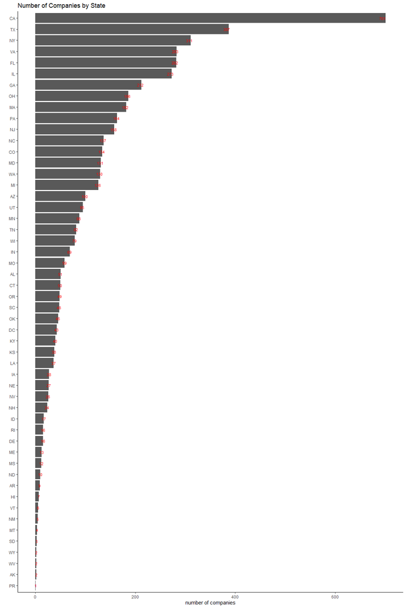

```r
inc %>%
        dplyr::select(State) %>%
        group_by(State) %>%
        summarise(n = n()) %>%
        ggplot(aes(x = reorder(State, n), y = n)) +
        geom_bar(stat = "identity") +
        coord_flip() +
        theme_classic() +
        labs(x = "", y = "number of companies") +
        ggtitle("Number of Companies by State") +
        geom_text(aes(label = n),
                  check_overlap = TRUE, size = 3, col = "red",
                  position = position_stack(vjust = 0.99))
```

## Quesiton 2

Lets dig in on the state with the 3rd most companies in the data set. Imagine you work for the state and are interested in how many people are employed by companies in different industries. Create a plot that shows the average and/or median employment by industry for companies in this state (only use cases with full data, use R’s `complete.cases()` function.) In addition to this, your graph should show how variable the ranges are, and you should deal with outliers.

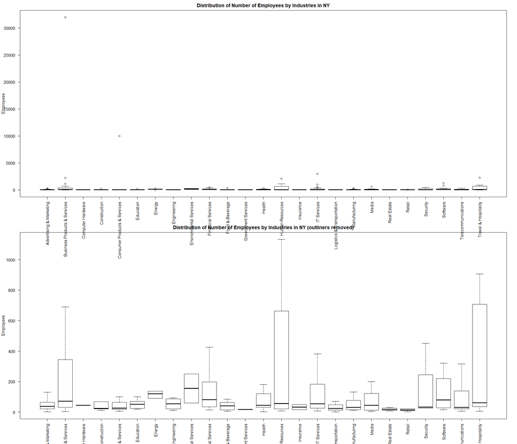

```r
target_state <- inc %>%
        dplyr::select(State) %>%
        group_by(State) %>%
        summarise(n = n()) %>%
        arrange(desc(n)) %>%
        dplyr::mutate(rank = row_number()) %>%
        dplyr::filter(rank == 3) %>%
        dplyr::select(State) %>%
        .[[1]] %>%
        as.character()

df <- inc %>%
        complete.cases() %>%
        inc[., ] %>%
        dplyr::filter(State == target_state) %>%
        dplyr::select(Industry, Employees)

par(mfrow = c(2, 1))
boxplot(Employees ~ Industry, data = df, las = 2, main = paste0("Distribution of Number of Employees by Industries in ", target_state), xlab = "")
boxplot(Employees ~ Industry, data = df, las = 2, outline = FALSE, main = paste0("Distribution of Number of Employees by Industries in ", target_state, " (outliners removed)"), xlab = "")
```

## Question 3

Now imagine you work for an investor and want to see which industries generate the most revenue per employee. Create a chart that makes this information clear. Once again, the distribution per industry should be shown.

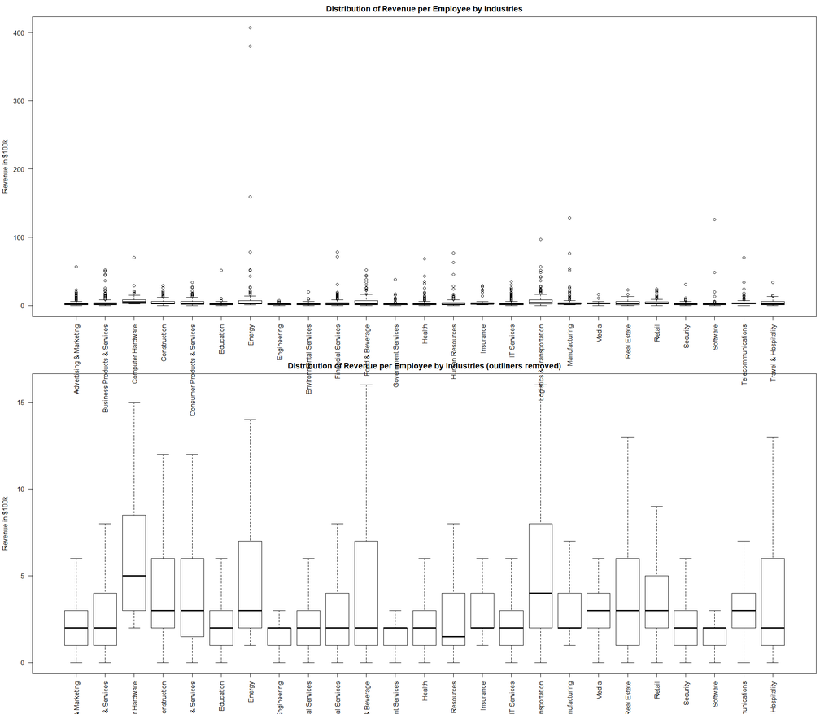

```r
df2 <- inc %>%
        complete.cases() %>%
        inc[., ] %>%
        dplyr::select(Industry, Employees, Revenue) %>%
        dplyr::mutate(Revenue_per_Employee = round( (Revenue/100000) / Employees, 0 ))

par(mfrow = c(2, 1))
boxplot(Revenue_per_Employee ~ Industry, data = df2, las = 2, main = "Distribution of Revenue per Employee by Industries", xlab = "", ylab = "Revenue in $100k")
boxplot(Revenue_per_Employee ~ Industry, data = df2, las = 2, outline = FALSE, main = "Distribution of Revenue per Employee by Industries (outliners removed)", xlab = "", ylab = "Revenue in $100k")
```